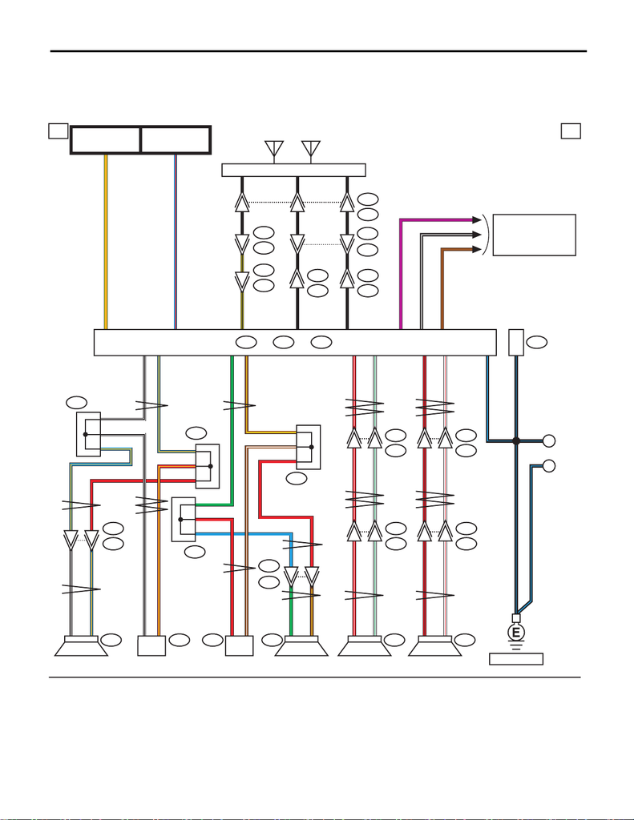

WI-84

Audio System

WIRING SYSTEM

8. Audio System

A: WIRING DIAGRAM

1. STANDARD MODEL (ENGINE TYPE FA)

2

1

2

1

6

5

6

5

7

6

6

5

WI-44294

i158D2 i159 D12 D29 D23

B

i85A: AN1E: AN2F:

1

A

i29

1a 1a

A7

A83

1 W/B

R/Y

W/B

W/B

W/B

L/O

L/O

L/O

R/Y

R

BR/Y

BR/W

R

i167

i166

J/C

J/C

i101

D84

1

2 W/B

L/O

L/O

R

W/B

L/O

Y/R

L/R

B

B

A20

Y/R

L/R

A3

A18

A171

3

BR/W

R

BR/Y

L

R

G

G

i168

i169

J/C

J/C

i76

D83

2

1 BR/Y

GL

R

A15

A16

R13

D28

i53

R98

i102

R167

1

2 R/W

GR/G

R/WR/W

GR/GGR/G

A5

A6

R10

D22

1

B/L

B/L

B/L

B/L

B/L A10

B/L 1

2 R/B

W/R

R/BR/B

W/RW/R

V

A1

B/WA2

BR

V

B/W

BR

A11

1

1

1

1

1

1

1

1

1

1

1

1

2

3

B

B

B

B

Y/B

B

B

Y/B

B

B

A9

E1

F1

1

AN15

AN11

1

AN6

AN4

3

AN5

AN3

1

AN8

R97

12

R167

i102

3

1

AN9

AN7

AUDIO BRACKET

GROUND

REF. TO CLEARANCE

LIGHT & ILLUMINATION

LIGHT SYSTEM

[1c] [1d] [2c] [2d]

REAR DOOR

SPEAKER LH

REAR DOOR

SPEAKER RH

SIDE

TWEETER RH

FRONT DOOR

SPEAKER RH

FB-10

M/B FUSE NO. 8

(B)

FB-25

F/B FUSE NO. 24

(ACC)

SIDE

TWEETER LH

FRONT DOOR

SPEAKER LH

REF. TO GND [e]

: TERMINAL No. OPTIONAL ARRANGEMENT

AUDIO

ANTENNA

SATELLITE

ANTENNA

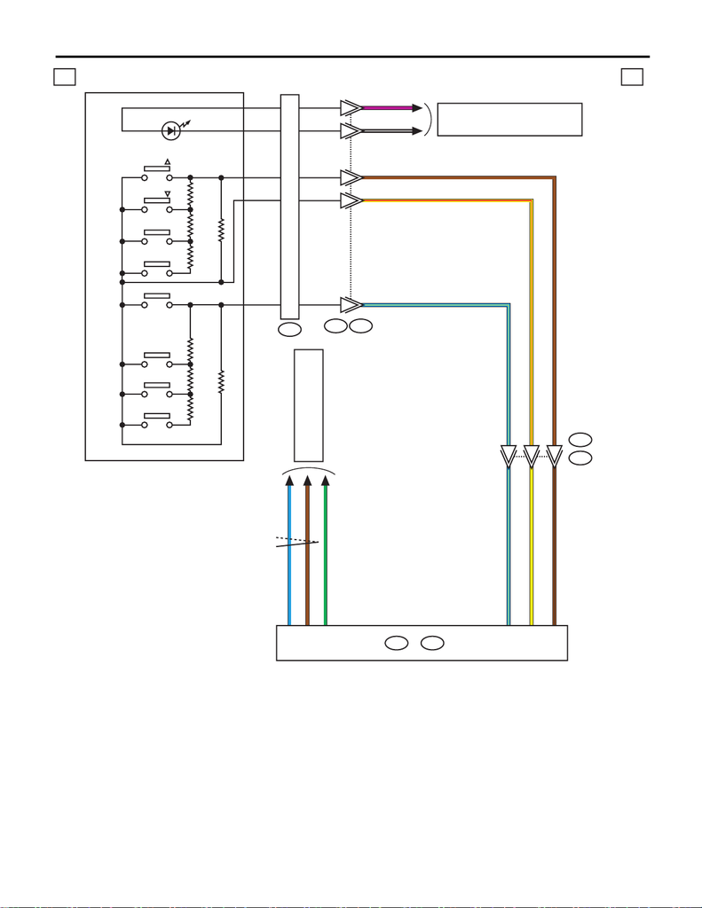

WI-85

Audio System

WIRING SYSTEM

i85A: i86B:

5

6

14

10

7

3

1

2

WI-44295

B553

ST3

1b 1b

VOL +

SEEK

SEEK

TALK

MODE

ON HOOK

OFF HOOK

i231

A4

A14

Y

BR/B

B68ST1

V

Y/R

L/Y

B/W

BR

2

12

6

10

11

A13

L/Y

Y

BR/B

L/Y

Y/R

BR

L/Y

B16 BR

B15 G

B8 L

BR

G

L

VOL –

REF. TO MULTI-FUNCTION

DISPLAY (MFD) SYSTEM [a]

ROLL

CONNECTOR

REF. TO CLEARANCE LIGHT &

ILLUMINATION LIGHT SYSTEM [1a] [2a]

SATELLITE SWITCH

AUDIO

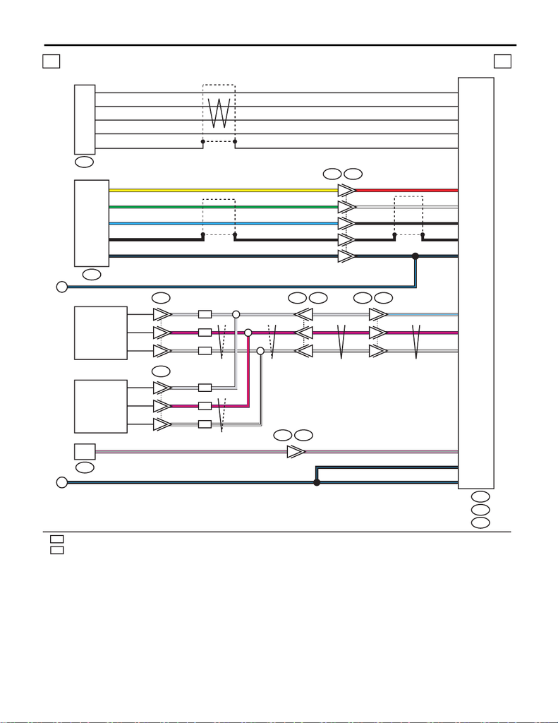

WI-86

Audio System

WIRING SYSTEM

AD15

F:

WI-44296

11

12

13

11

5

6

4

4

1

2

3

5

17

18

19

1c 1c

OR

WR

R382

i195

R50 B90R56

B552

i230

B584 i238

R284

i85

A:

i86

B:

A

B310

B

B4

B3

B11

B12

2

6

4

L

G

Y

1S

5 B/L

L

G

S

B/L

Y

B

W

R

S

B/L

B/L

GR

V/R

W/B

GR

V/R

W/B

GR

V/R

W/B

B

W

S

B10B/L

R

B9

B2

B1

V/R

GR/L

W/B

A19P/G

B7B/L

GR/L

V/R

W/B

GR

V/R

W/B

P/G30 P/GP/G

B/L

A12B/L

VDC CM

OR

OR

OR

B5

B6

B4

GR

V/R

W/B

WR

WR

WR

R62

B:

1

1

F1

F3

F4

F2

2

4

3

1

AD16

SPOT MAP LIGHT

(MICROPHONE)

SPOT MAP LIGHT

(MICROPHONE)

AUX INPUT TERMINAL

AUDIO

: WITHOUT SUNROOF

: WITH SUNROOF

AUX INPUT

TERMINAL (USB)

1

: SHIELD CONNECTOR

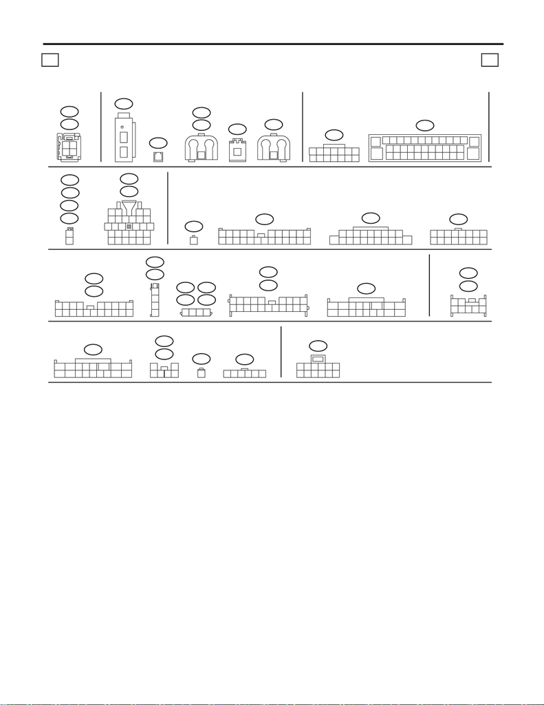

WI-87

Audio System

WIRING SYSTEM

1

2

AN6

AN1

(GR)

E:

F:

F:

AN2

1

(G)

1

ST3

2

1

89

5

12

6

7

34

1110

AD16

(GR)

AD15

(GR)

WI-44297

1d 1d

R97

R50

R284

D84

D83

B68

3

42

156

7

13 1411

12

9

10

8

B310

23456789

1

10 11 12 13

14

15

26

16 17 18 19 20 21 22 23 24 25

27 28 29 30 31 32 33 34 35 36 37

38

19

18

20 21 22

1514131211

1

3

24

5

7

6

98

10

17

25

24

26 27 2823

16

i29

1

i238

i102

i53

i86B:

i85

A:

3412 89

10 11

12 13 14 15 16 17 18 19 20 21 22 23 24

567

19

18

20

132

4

5

7

6

98

1514131211 1716

10

15

16

13

1411

12

9

10

78563412

89

19 20

1234 567

10 11 12 13 14 15 16 17 18

1

2

D23

D29

D12

D2

i159

i158

i169

i168

i167

i166

i230

1234

1

3

4

2

i195

(GR)

(GR)

10

13

345 6

14 15 16 17

1211

12 78

9

i231

12345 6789

10 11 12 13 14 15 16 17 18 19 20

R13

R10

65

21

4

3

87

10

13

345 6

14 15 16 17

1211

12 78

9

1123456

R62B:

R56

5634

21

AN15

(GR)

2

13

AN5

AN7

2

13

12

34

LIST OF CONNECTORS

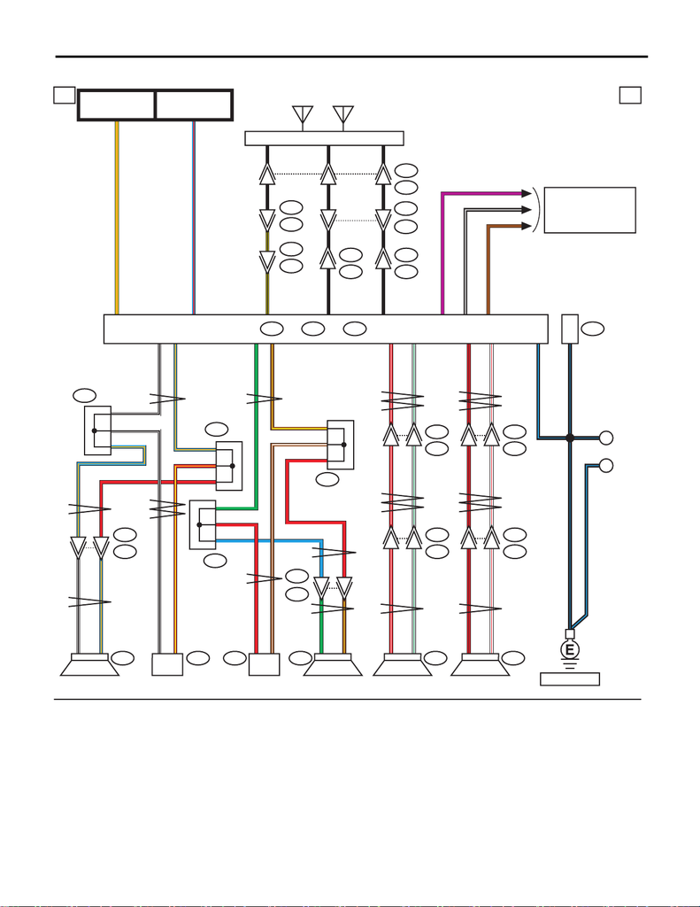

WI-88

Audio System

WIRING SYSTEM

2. STANDARD MODEL (ENGINE TYPE EJ)

2

1

2

1

6

5

6

5

7

6

6

5

WI-44631

i158D2 i159 D12 D29 D23

B

i85A: AN1E: AN2F:

1

A

i29

2a 2a

A7

A83

1 W/B

R/Y

W/B

W/B

W/B

L/O

L/O

L/O

R/Y

R

BR/Y

BR/W

R

i167

i166

J/C

J/C

i101

D84

1

2 W/B

L/O

L/O

R

W/B

L/O

Y/R

L/R

B

B

A20

Y/R

L/R

A3

A18

A171

3

BR/W

R

BR/Y

L

R

G

G

i168

i169

J/C

J/C

i76

D83

2

1 BR/Y

GL

R

A15

A16

R13

D28

i53

R98

i102

R167

1

2 R/W

GR/G

R/WR/W

GR/GGR/G

A5

A6

R10

D22

1

B/L

B/L

B/L

B/L

B/L A10

B/L 1

2 R/B

W/R

R/BR/B

W/RW/R

V

A1

B/WA2

BR

V

B/W

BR

A11

1

1

1

1

1

1

1

1

1

1

1

1

2

3

B

B

B

B

Y/B

B

B

Y/B

B

B

A9

E1

F1

1

AN15

AN11

1

AN6

AN4

3

AN5

AN3

1

AN8

R97

12

R167

i102

3

1

AN9

AN7

AUDIO BRACKET

GROUND

REF. TO CLEARANCE

LIGHT & ILLUMINATION

LIGHT SYSTEM

[1c] [1d] [2c] [2d]

REAR DOOR

SPEAKER LH

REAR DOOR

SPEAKER RH

SIDE

TWEETER RH

FRONT DOOR

SPEAKER RH

FB-10

M/B FUSE NO. 8

(B)

FB-25

F/B FUSE NO. 24

(ACC)

SIDE

TWEETER LH

FRONT DOOR

SPEAKER LH

REF. TO GND [e]

: TERMINAL No. OPTIONAL ARRANGEMENT

AUDIO

ANTENNA

SATELLITE

ANTENNA

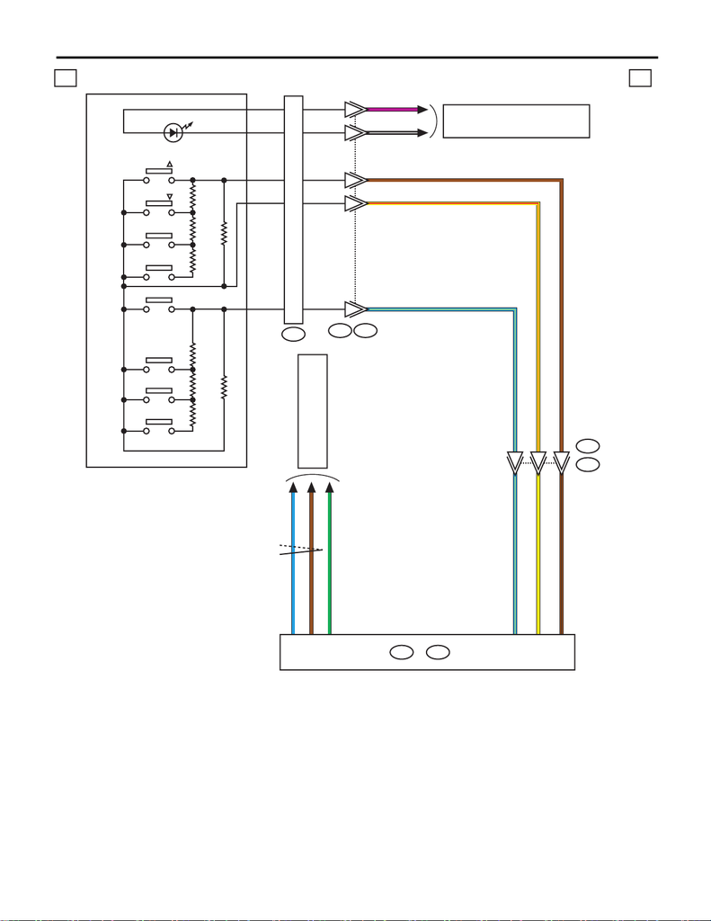

WI-89

Audio System

WIRING SYSTEM

i85A: i86B:

5

6

14

10

7

3

1

2

WI-44632

B553

ST3

2b 2b

VOL +

SEEK

SEEK

TALK

MODE

ON HOOK

OFF HOOK

i231

A4

A14

Y

BR/B

B68ST1

V

Y/R

L/Y

B/W

BR

2

12

6

10

11

A13

L/Y

Y

BR/B

L/Y

Y/R

BR

L/Y

B16 BR

B15 G

B8 L

BR

G

L

VOL –

REF. TO MULTI-FUNCTION

DISPLAY (MFD) SYSTEM [a]

ROLL

CONNECTOR

REF. TO CLEARANCE LIGHT &

ILLUMINATION LIGHT SYSTEM [1a] [2a]

SATELLITE SWITCH

AUDIO

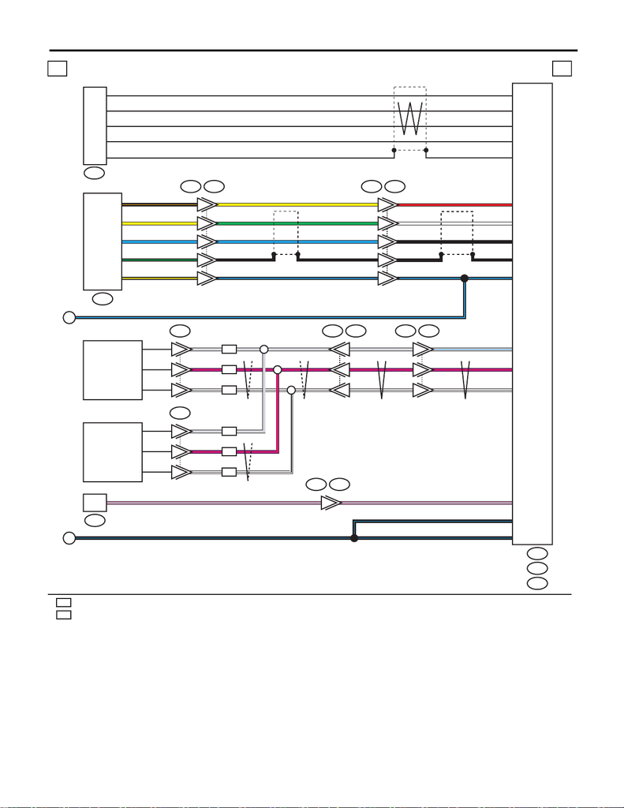

WI-90

Audio System

WIRING SYSTEM

WI-44633

11

12

13

11

5

6

4

4

1

2

3

5

17

18

19

2c 2c

OR

WR

R382

i195

R50 B90R56

B552

i230

B584 i238

i85

A:

i86

B:

A

B310

B

B4

B3

B11

B10

B12

B

W

R

S

B/L B/L

B/L

GR

V/R

W/B

GR

V/R

W/B

GR

V/R

W/B

B

W

S

R

B9

B2

B1

V/R

GR/L

W/B

A19P/G

B7B/L

GR/L

V/R

W/B

GR

V/R

W/B

P/G30 P/GP/G

B/L

A12B/L

VDC CM

OR

OR

OR

B5

B6

B4

GR

V/R

W/B

WR

WR

WR

R62

B:

L

G

S

B/L

Y

10

12

9

AD6

R34

AD7

6

1

4

Y

B/G

B/O

2L

5 B/Y

G

S

Y

L

B/L

8

11

1

AD16

AD15

F:

OVERHEAD CONSOLE

(HANDSFREE MICROPHONE)

OVERHEAD CONSOLE

(HANDSFREE MICROPHONE)

AUDIO

: WITHOUT SUNROOF

: WITH SUNROOF

1

1

F1

F3

F4

F2

2

4

3

1

AUX INPUT

TERMINAL (USB)

: SHIELD CONNECTOR

AUX INPUT TERMINAL

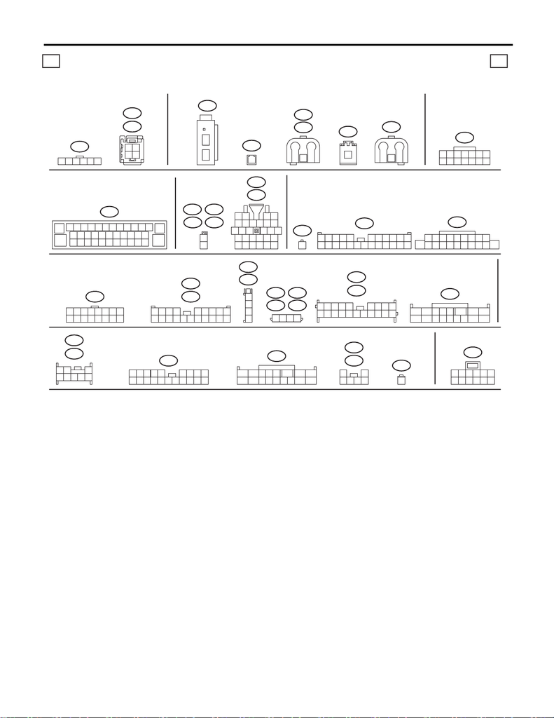

WI-91

Audio System

WIRING SYSTEM

AN6

F:

AN2

1

(G)

1

ST3

2

1

89

5

12

6

7

34

1110

AD7

123456

WI-44634

2d 2d

R97

R50

D84

D83

B68

3

42

156

7

13 1411

12

9

10

8

B310

23456789

1

10 11 12 13

14

15

26

16 17 18 19 20 21 22 23 24 25

27 28 29 30 31 32 33 34 35 36 37

38

19

18

20 21 22

1514131211

1

3

24

5

7

6

98

10

17

25

24

26 27 2823

16

i29

1

i102

i53

i86B:

i85

A:

3412 89

10 11

12 13 14 15 16 17 18 19 20 21 22 23 24

567

19

18

20

132

4

5

7

6

98

1514131211 1716

10

15

16

13

1411

12

9

10

78563412

89

19 20

1234 567

10 11 12 13 14 15 16 17 18

1

2

D23

D29

D12

D2

i159

i158

i169

i168

i167

i166

i230

1234

1

3

4

2

i195

(GR)

(GR)

10

13

345 6

14 15 16 17

1211

12 78

9

i231

12345 6789

10 11 12 13 14 15 16 17 18 19 20

i238

R13

R10

65

21

4

3

87

10

13

345 6

14 15 16 17

1211

12 78

9

1

R62B:

R34

123

161514

546789

17 18 19 2013121110

R56

5634

21

AN15

(GR)

2

13

AN5

AN7

2

13

AN1

(GR)

E:

(GR)

AD16

F:

(GR)

AD15

1

2

12

34

LIST OF CONNECTORS

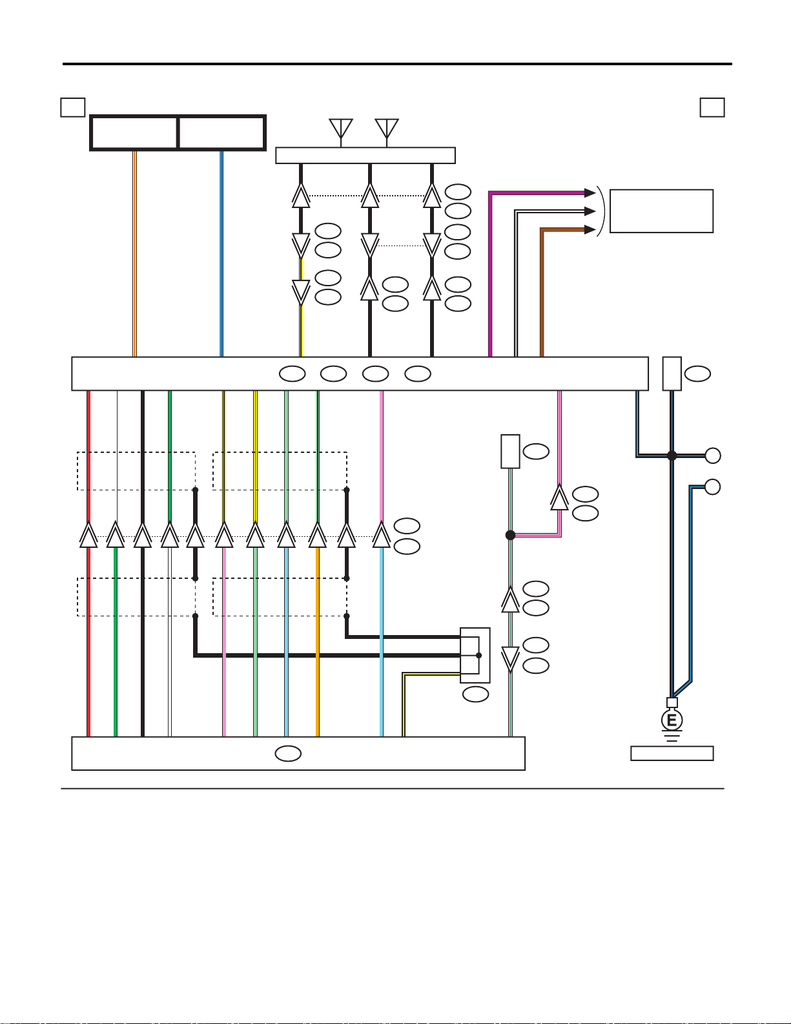

WI-92

Audio System

WIRING SYSTEM

3. PREMIUM MODEL (ENGINE TYPE FA)

WI-44298

23

B

i86B:i85A:

R386A:

A

i29

B310

3a 3a

1

R3

B99

Y/R

L/RA20

Y/R

L/R

A3

R14

J/C

B/L

B/L

B/L

B/L

B/L A10

P/G A19

B/L 1

V

A1

B/WA2

BR

V

B/W

BR

A11

1

1

1

P/G

P/G

30

A5

A4

A3

A2

A23

A22

A18

A17

A12

R A18

W A17

BA8

G

S

S

S

S

A7

Y/B A16

Y/R A15

LG A6

LG/B A5

P

R

G

B

W

P

LG

SB

O

SB

A6 B/Y

A11 P/G

B/Y

S

S

B5

P/G

P/G

VDC CM

11

i230

B552

R81

R82

19

20

8

9

7

19

18

11

6

10

13

12

i195

R382

AN1E: AN2F:

2

3

1

AN15

AN11

AN6

AN4

3

AN5

AN3

1

AN8

R97

12

R167

i102

3

1

AN9

AN7

Y/B

B

B

A9

E1

F1

1

B

B

B

B

B

B

Y/B

B

B

AUDIO BRACKET

GROUND

REF. TO CLEARANCE

LIGHT & ILLUMINATION

LIGHT SYSTEM

[1c] [1d] [2c] [2d]

FB-10

M/B FUSE NO. 8

(B)

FB-25

F/B FUSE NO. 24

(ACC)

: TERMINAL No. OPTIONAL ARRANGEMENT

REF. TO GND [e]

AUDIO AMPLIFIER

AUDIO

ANTENNA

SATELLITE

ANTENNA

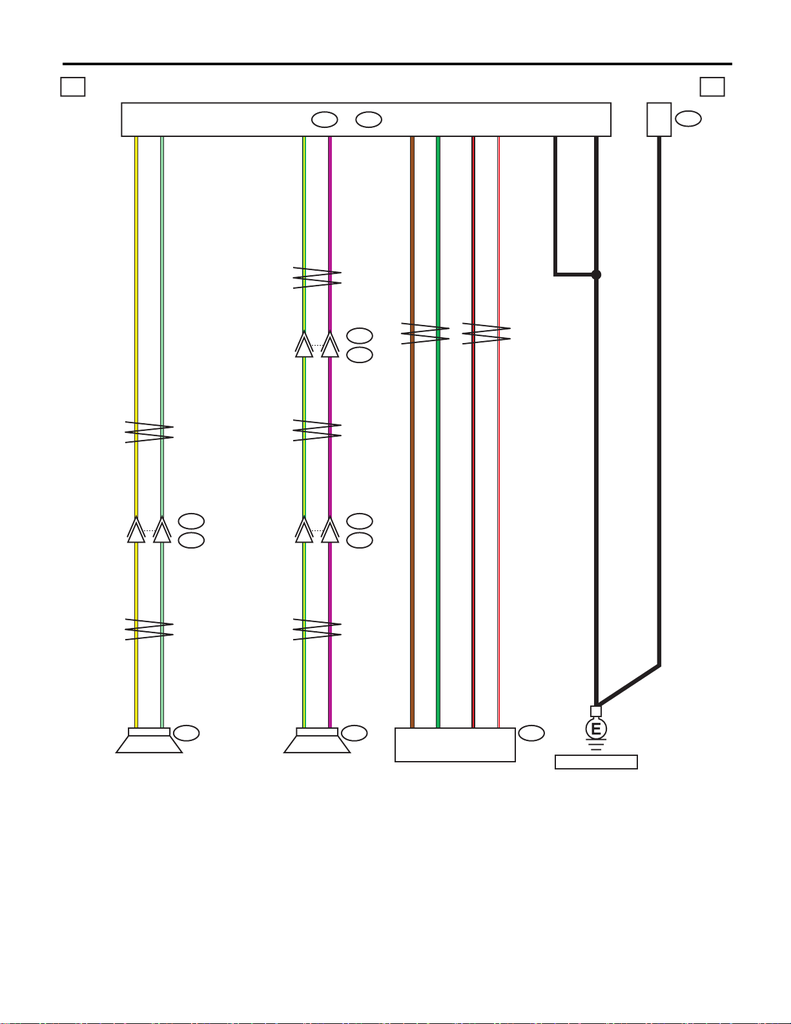

WI-93

Audio System

WIRING SYSTEM

WI-44299

5

6

5

6

R317

R17

C:R316B:

3b 3b

D29 D23 R117

D22

R10

D28

R13

13

14

R81

R82

B8

B71

2Y

LG

Y

LGLG

LG

Y

Y

B2

B61

3

4

2 G/Y

V

G/Y

V

C5

C12

BR

G

C6

C7

B

B

G

BR

1

2

C4

C10

B/R

W/R

W/R

B/R

V

V

G/Y

G/Y

B

1B

B

REAR DOOR

SPEAKER LH (LOW)

WOOFER

REAR DOOR

SPEAKER RH (LOW)

REF. TO GND [g]

AUDIO AMPLIFIER

AMPLIFIER

BRACKET GROUND

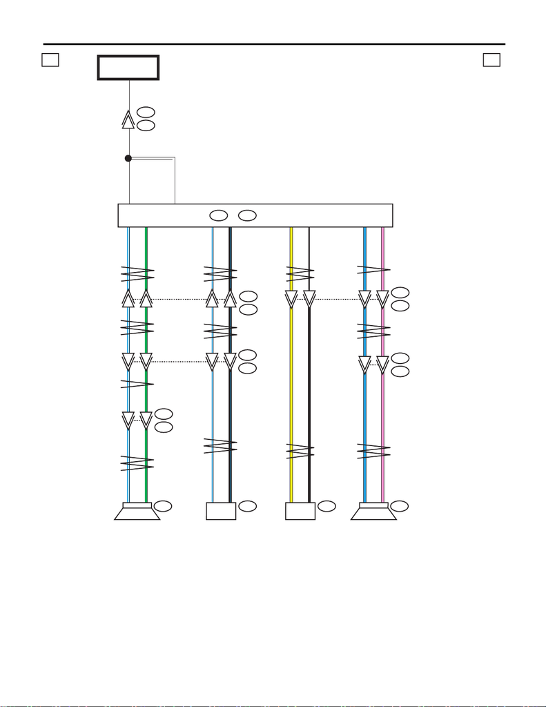

WI-94

Audio System

WIRING SYSTEM

WI-44300

11

2

2

1

R316B: R317C:

3c 3c

D2

R1

B97

i159

D84

i101

19

20

D12

D83

i76

6

7

i53

R98

B10

W

B4

B1

1

2 L/W

G

L/W

G

L/W

G

WB5

WW

C1Y

C2W/B

2

1Y

B

G

G

L/W

L/W

B3

B91

2L

P

L

PP

P

L

L

15

8

i158

C3W/L

C9B/L

W/L

B/L

W/L

B/L

2

1 W/L

B/L

18

17

i102

R167

18

17

R82

15

16

R81

FRONT DOOR SPEAKER RHSIDE TWEETER RHSIDE TWEETER LH

MB-3

M/B FUSE NO. 5

(B)

FRONT DOOR SPEAKER LH

AUDIO AMPLIFIER

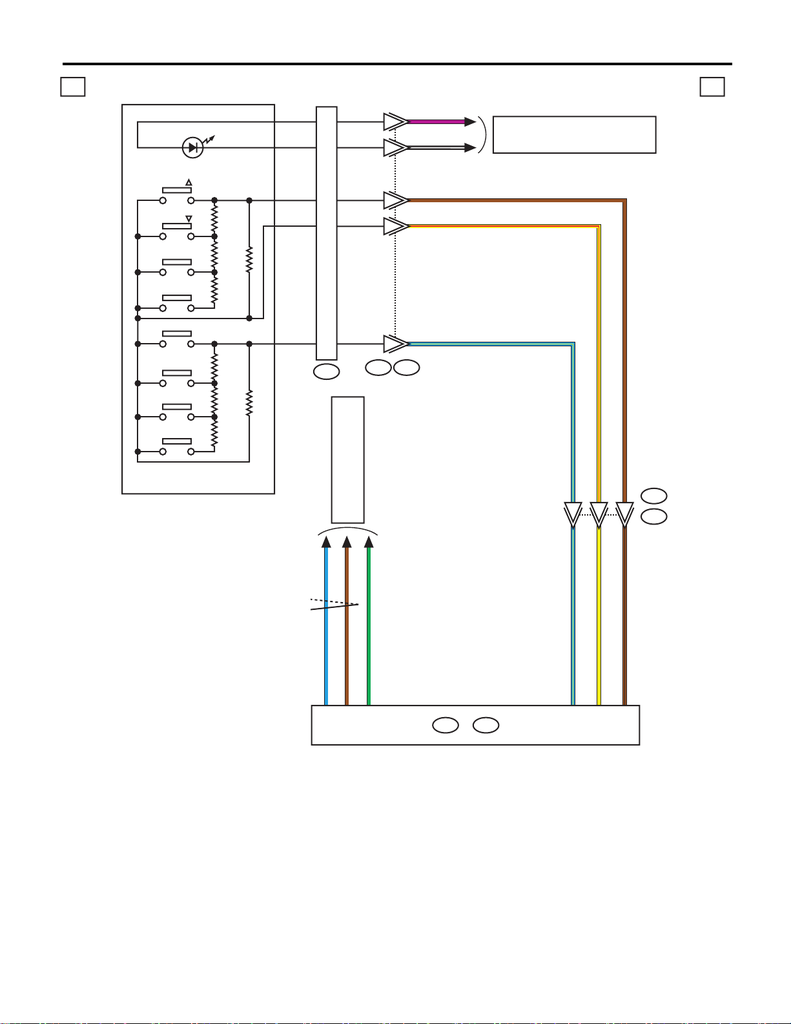

WI-95

Audio System

WIRING SYSTEM

i85A: i86B:

5

6

14

10

7

3

1

2

WI-44301

B553

ST3

3d 3d

VOL +

SEEK

SEEK

TALK

MODE

ON HOOK

OFF HOOK

i231

A4

A14

Y

BR/B

B68ST1

V

Y/R

L/Y

B/W

BR

2

12

6

10

11

A13

L/Y

Y

BR/B

L/Y

Y/R

BR

L/Y

B16 BR

B15 G

B8 L

BR

G

L

VOL –

REF. TO MULTI-FUNCTION

DISPLAY (MFD) SYSTEM [a]

ROLL

CONNECTOR

REF. TO CLEARANCE LIGHT &

ILLUMINATION LIGHT SYSTEM [1a] [2a]

SATELLITE SWITCH

AUDIO

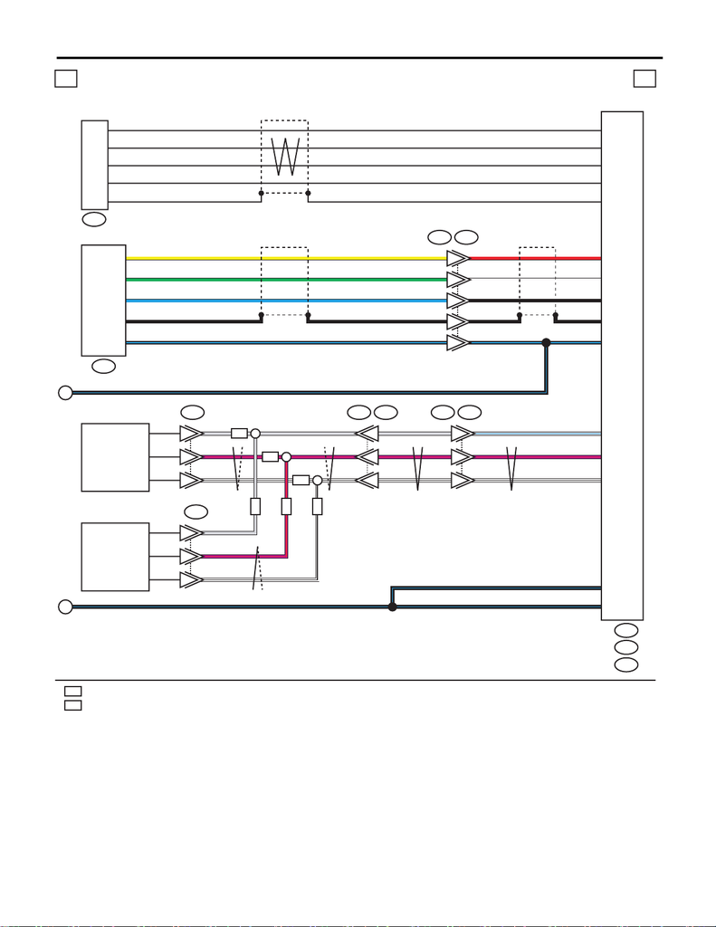

WI-96

Audio System

WIRING SYSTEM

WI-46869

12

13

11

5

6

4

17

18

19

B6

B4

B5

3e 3e

R50

B90

R56 B584 i238

i85

A:

i86

B:

B

OR

WR

WR

WR

OR

OR

GR

V/R

W/B

GR

V/R

W/B

GR

V/R

W/B

B9

B2

B1

V/R

GR/L

W/B

B7B/L

GR/L

V/R

W/B

GR

V/R

W/B

B/L

GR

V/R

W/B

A12B/L

R62

B:

1

AD15

F:

OR

WR

R382

i195

R284

AD16

4

1

2

3

5

B4

B3

B11

B10

B12

L

G

Y

S

B/L

L

G

S

B/L

Y

B

W

R

S

B/L

B

W

S

R

1

1

F1

F3

F4

F2

2

4

3

1

A

2

6

4

1

5

B/L

SPOT MAP LIGHT

(MICROPHONE)

SPOT MAP LIGHT

(MICROPHONE)

AUDIO

AUX INPUT TERMINAL

AUX INPUT

TERMINAL (USB)

: SHIELD CONNECTOR

: WITHOUT SUNROOF

: WITH SUNROOF

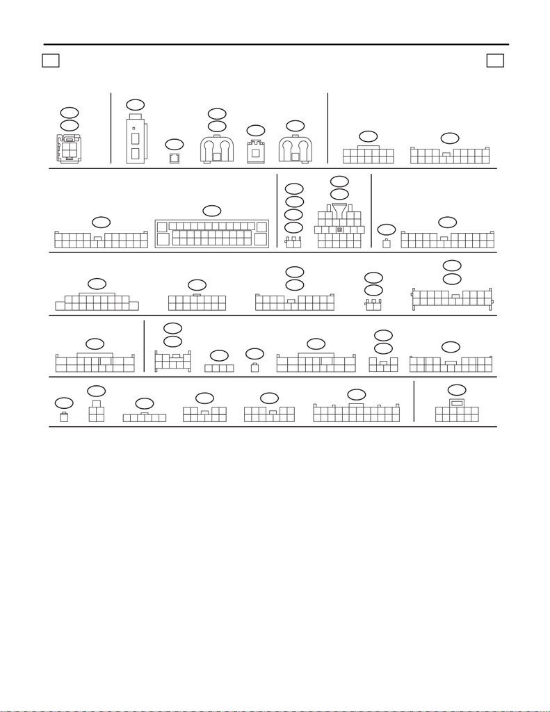

WI-97

Audio System

WIRING SYSTEM

AN6

AN1

(GR)

E:

F:

F:

AN2

1

(G)

1

ST3

2

1

89

5

12

6

7

34

1110

AD16

(GR)

AD15

(GR)

R17

(B)

1

WI-44303

3f 3f

D84

D83

B68

3

42

156

7

13 1411

12

9

10

8

B310

23456789

1

10 11 12 13

14

15

26

16 17 18 19 20 21 22 23 24 25

27 28 29 30 31 32 33 34 35 36 37

38

19

18

20 21 22

1514131211

1

3

24

5

7

6

98

10

17

25

24

26 27 2823

16

i29

1

12

D23

D29

D12

D2

i159

i158

i102

i86B:

i85

A:

19

18

20

132

4

5

7

6

98

1514131211 1716

10

15

16

13

1411

12

9

10

78563412

89

19 20

1234 567

10 11 12 13 14 15 16 17 18

12

i230

i195

(GR)

10

13

345 6

14 15 16 17

1211

12 78

9

i231

12345 6789

10 11 12 13 14 15 16 17 18 19 20

i238

R97

R82

R284

(B)

R50

(GR)

R13

R10

65

21

4

3

87

10

13

345 6

14 15 16 17

1211

12 78

9

1123456

1

9

234 5678

10 11 12 14 15 16 17 18 1913

R62B:

R56

5634

21

3412 89

10 11

12 13 14 15 16 17 18 19 20 21 22 23 24

567

B99

1234

R14

R386

A:

R316

B:

R317

C:

R117

i53

123456789101112

13 14 15 16 17 18 19 20 21 22 23 24

12

34

56789

10

123 45

6 7 8 9 10 11 12

12

34

3412 89

10 11

12 13 14 15 16 17 18 19 20 21 22 23 24

567

AN15

(GR)

2

13

AN5

AN7

2

13

12

34

1

2

89

19 20

1234 567

10 11 12 13 14 15 16 17 18

B97

LIST OF CONNECTORS

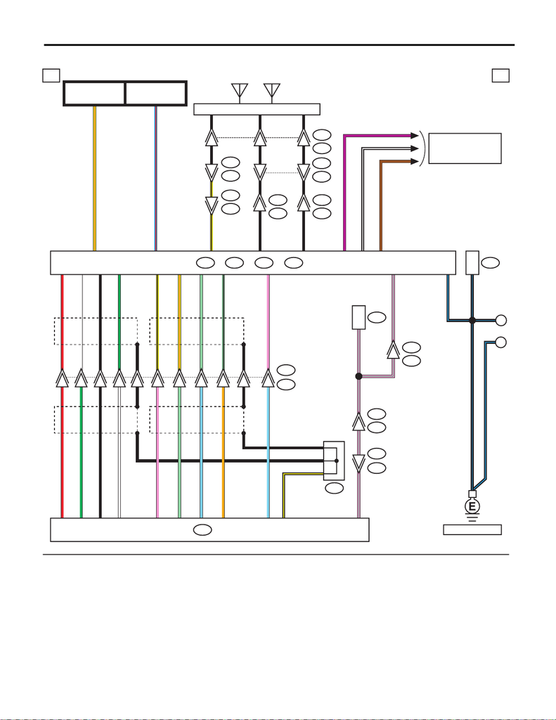

WI-98

Audio System

WIRING SYSTEM

4. PREMIUM MODEL (ENGINE TYPE EJ)

WI-44635

23

B

i86B:i85A:

R386A:

A

i29

B310

4a 4a

1

R3

B99

Y/R

L/RA20

Y/R

L/R

A3

R14

J/C

B/L

B/L

B/L

B/L

B/L A10

P/G A19

B/L 1

V

A1

B/WA2

BR

V

B/W

BR

A11

1

1

1

P/G

P/G

30

A5

A4

A3

A2

A23

A22

A18

A17

A12

R A18

W A17

BA8

G

S

S

S

S

A7

Y/B A16

Y/R A15

LG A6

LG/B A5

P

R

G

B

W

P

LG

SB

O

SB

A6 B/Y

A11 P/G

B/Y

S

S

B5

P/G

P/G

VDC CM

11

i230

B552

R81

R82

19

20

8

9

7

19

18

11

6

10

13

12

i195

R382

AN1E: AN2F:

2

3

1

AN15

AN11

AN6

AN4

3

AN5

AN3

1

AN8

R97

12

R167

i102

3

1

AN9

AN7

Y/B

B

B

A9

E1

F1

1

AUDIO BRACKET

GROUND

REF. TO CLEARANCE

LIGHT & ILLUMINATION

LIGHT SYSTEM

[1c] [1d] [2c] [2d]

FB-10

M/B FUSE NO. 8

(B)

FB-25

F/B FUSE NO. 24

(ACC)

: TERMINAL No. OPTIONAL ARRANGEMENT

REF. TO GND [e]

AUDIO AMPLIFIER

AUDIO

B

B

B

B

B

B

Y/B

B

B

ANTENNA

SATELLITE

ANTENNA

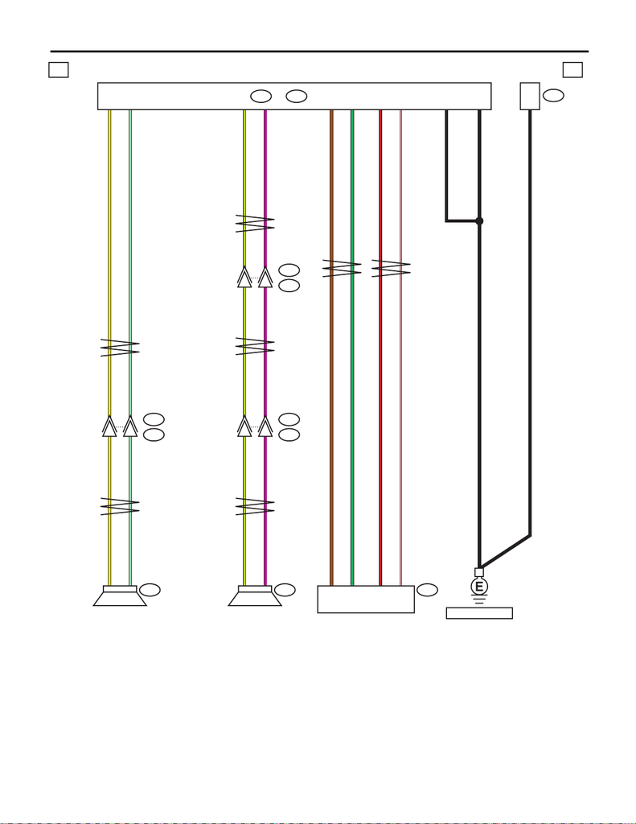

WI-99

Audio System

WIRING SYSTEM

WI-44636

5

6

5

6

R317

R17

C:R316B:

4b 4b

D29 D23 R117

D22

R10

D28

R13

13

14

R81

R82

B8

B71

2Y

LG

Y

LGLG

LG

Y

Y

B2

B61

3

4

2 G/Y

V

G/Y

V

C5

C12

BR

G

C6

C7

B

B

G

BR

1

2

C4

C10

B/R

W/R

W/R

B/R

V

V

G/Y

G/Y

B

1B

B

REAR DOOR

SPEAKER LH (LOW)

WOOFER

REAR DOOR

SPEAKER RH (LOW)

REF. TO GND [g]

AUDIO AMPLIFIER

AMPLIFIER

BRACKET GROUND

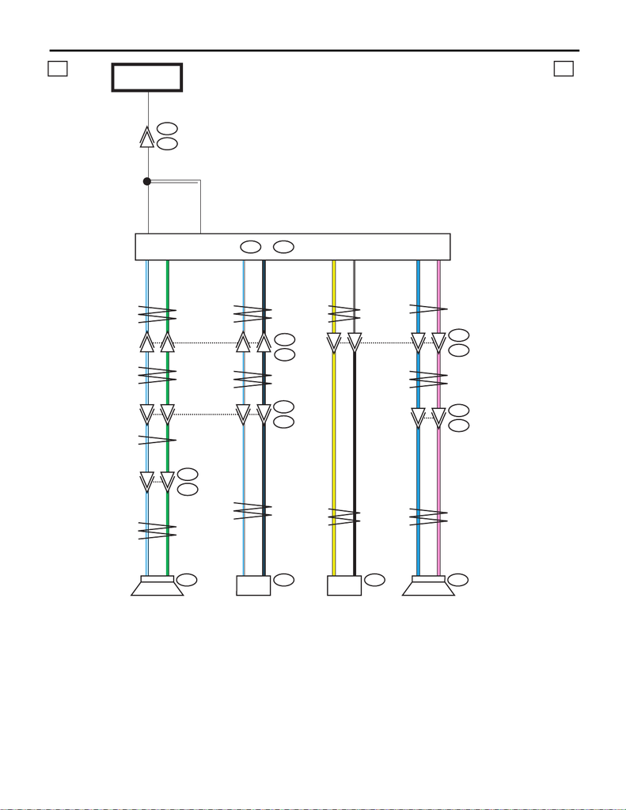

WI-100

Audio System

WIRING SYSTEM

WI-44637

11

2

2

1

R316B: R317C:

4c 4c

D2

R1

B97

i159

D84

i101

19

20

D12

D83

i76

6

7

i53

R98

B10

W

B4

B1

1

2 L/W

G

L/W

G

L/W

G

WB5

WW

C1Y

C2W/B

2

1Y

B

G

G

L/W

L/W

B3

B91

2L

P

L

PP

P

L

L

15

8

i158

C3W/L

C9B/L

W/L

B/L

W/L

B/L

2

1 W/L

B/L

18

17

i102

R167

18

17

R82

15

16

R81

FRONT DOOR SPEAKER RHSIDE TWEETER RHSIDE TWEETER LH

MB-3

M/B FUSE NO. 5

(B)

FRONT DOOR SPEAKER LH

AUDIO AMPLIFIER

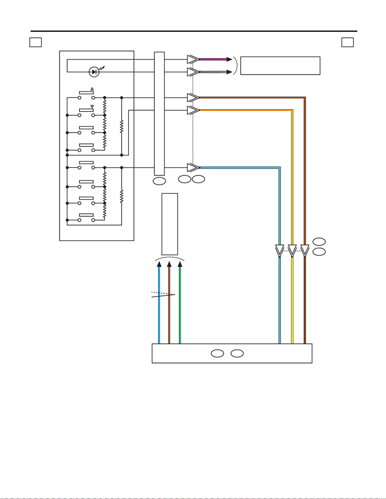

WI-101

Audio System

WIRING SYSTEM

i85A: i86B:

5

6

14

10

7

3

1

2

WI-45440

B553

ST3

4d 4d

VOL +

SEEK

SEEK

TALK

MODE

ON HOOK

OFF HOOK

i231

A4

A14

Y

BR/B

B68ST1

V

Y/R

L/Y

B/W

BR

2

12

6

10

11

A13

L/Y

Y

BR/B

L/Y

Y/R

BR

L/Y

B16 BR

B15 G

B8 L

BR

G

L

VOL –

REF. TO MULTI-FUNCTION

DISPLAY (MFD) SYSTEM [a]

ROLL

CONNECTOR

REF. TO CLEARANCE LIGHT &

ILLUMINATION LIGHT SYSTEM [1a] [2a]

SATELLITE SWITCH

AUDIO

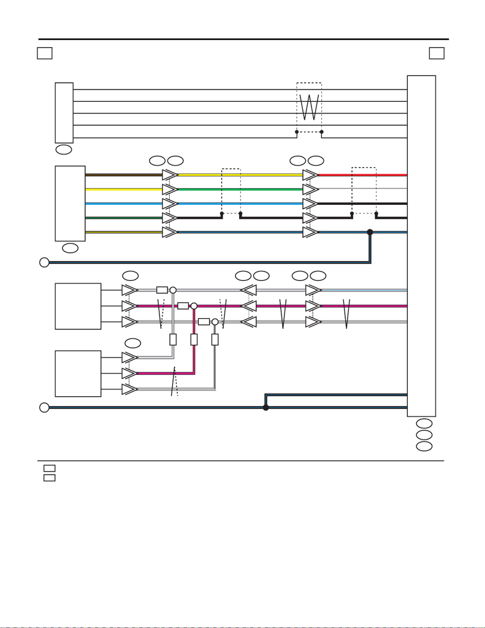

WI-102

Audio System

WIRING SYSTEM

WI-46870

12

13

11

5

6

4

17

18

19

B6

B4

B5

4e 4e

R50

B90

R56 B584 i238

i85

A:

i86

B:

AD15

F:

B

OR

WR

WR

WR

OR

OR

GR

V/R

W/B

GR

V/R

W/B

GR

V/R

W/B

B9

B2

B1

V/R

GR/L

W/B

B7B/L

GR/L

V/R

W/B

GR

V/R

W/B

B/L

GR

V/R

W/B

A12B/L

R62

B:

1

1

F1

F3

F4

F2

2

4

3

1

AD16

1

OR

WR

R382

i195

A

AD6

R34

Y

B/G

B/O

L

B/Y

G

S

Y

L

B/L

L

G

S

B/L

Y

B

W

R

S

B/L

B4

B3

B11

B10

B12

B

W

S

R

6

1

4

2

5

4

1

2

3

5

10

8

12

9

11

AD7

B/L

STEREO CAMERA COVER

(MICROPHONE)

OVERHEAD CONSOLE

(HANDSFREE MICROPHONE)

AUDIO

AUX INPUT TERMINAL

AUX INPUT

TERMINAL (USB)

: SHIELD CONNECTOR

: WITHOUT SUNROOF

: WITH SUNROOF

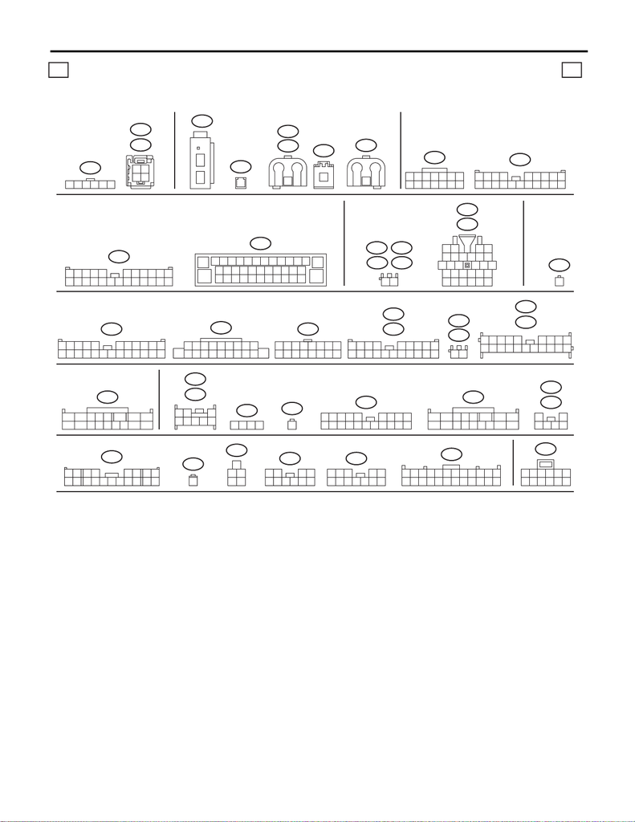

WI-103

Audio System

WIRING SYSTEM

AN6

F:

AN2

1

(G)

1

ST3

2

1

89

5

12

6

7

34

1110

AD7

123456

R17

(B)

1

WI-45442

4f 4f

D84

D83

B68

3

42

156

7

13 1411

12

9

10

8

B310

23456789

1

10 11 12 13

14

15

26

16 17 18 19 20 21 22 23 24 25

27 28 29 30 31 32 33 34 35 36 37

38

19

18

20 21 22

1514131211

1

3

24

5

7

6

98

10

17

25

24

26 27 2823

16

i29

1

12

D23

D29

D12

D2

i159

i158

i102

i86B:

i85

A:

19

18

20

132

4

5

7

6

98

1514131211 1716

10

15

16

13

1411

12

9

10

78563412

89

19 20

1234 567

10 11 12 13 14 15 16 17 18

12

i230

i195

(GR)

10

13

345 6

14 15 16 17

1211

12 78

9

i231

12345 6789

10 11 12 13 14 15 16 17 18 19 20

i238

R97

R82

(B)

R50

(GR)

R13

R10

65

21

4

3

87

10

13

345 6

14 15 16 17

1211

12 78

9

1

1

9

234 5678

10 11 12 14 15 16 17 18 1913

R62B:

R34

123

161514

546789

17 18 19 2013121110

R56

5634

21

3412 89

10 11

12 13 14 15 16 17 18 19 20 21 22 23 24

567

B99

1234

R14

R386

A:

R316

B:

R317

C:

R117

i53

123456789101112

13 14 15 16 17 18 19 20 21 22 23 24

12

34

56789

10

123 45

6 7 8 9 10 11 12

12

34

3412 89

10 11

12 13 14 15 16 17 18 19 20 21 22 23 24

567

AN15

(GR)

2

13

AN5

AN7

2

13

AN1

(GR)

E:

1

2

(GR)

AD16

F:

(GR)

AD15

12

34

89

19 20

1234 567

10 11 12 13 14 15 16 17 18

B97

LIST OF CONNECTORS